# Binomial Logistic Regression (Linear Regression Evolution

[figure not shown]

# Import data

```r
draft_unreal <- read.csv("C:/Users/GrandProf/Downloads/Repos_4cleanup/Repositories_AP7/On_GitHub/BinomReg/data/draft_unreal.csv")
```

## Test for Correlation

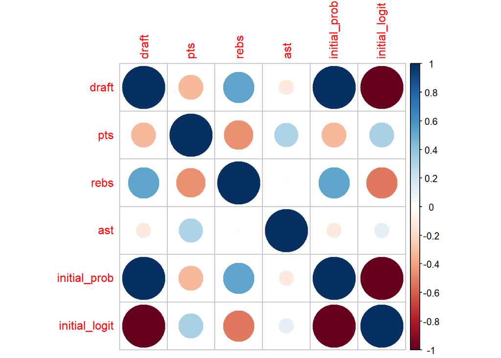

```r
draft_unreal$initial_prob <- ifelse(draft_unreal$draft==1,0.6,0.4)
draft_unreal$initial_logit <- ifelse(draft_unreal$draft==1,log(0.6/1.6),(1-log(0.6/1.6)))
draft_cormatrix <- cor(draft_unreal)
library(corrplot) # me preferably not ggcorrplot
corrplot(cor(draft_unreal))
```

## Why Binomial Regression?

- Poor correlation between Bernoulli observations and predictors
- Poor Correlation between derived or calculated probabilities and predictors
- Poor correlation between the log(OR) derived from initial probabilities and predictors
- Unable to fit predictor variables to a commonly known models hence making it difficult to make a judgement call as to IF the predictors should be included in the binomial regression equation
- Unable to fit the response variable to commonly known models (normal etc.) hence leading to difficulties in interpreting the results of the binomial regression

## Why the use of a Logit function?

- Constraints on using the probability directly (could lead to negative values in the probability).
- Other mathematical constraints exists when taking the LN(prob) which could lead to probability values out of range
- The solution is the Logit link which ensures that probability values obtained are within range

## Logit function

$$\frac{π_i}{1-π_i} = \frac{e^{β_o+β_1 x_i
}}{1 + e^{β_o+β_1 x_i}}$$

$$θ_{i}=β_o+β_1 x_i$$

## Hypothesis

### Mathematical

- NULL: $Log(\frac{π_i}{1-π_i}) \neq 0$
- ALTERNATE: $Log(\frac{π_i}{1-π_i}) = 0$

## Procedure

1. Guess initial coefficients ($β_o$, $β_1$ etc.) of $θ_i$
2. Estimate $θ_i$
3. Exponentiation of $θ_i$
4. Calculate the probability of success $π_i$ vs failure $1 - π_i$
5. Logit = $Log(π_i)$ for 1 vs $Log(1-π_i)$ for 0
6. Use a maximization function to determine the final coefficients
7. Remember that the actual probability is $θ_i$

## Procedure in R

```r
m1 <- glm(draft ~ pts + rebs + ast, family = binomial, data = draft_unreal)
summary(m1)
```

```
##
## Call:
## glm(formula = draft ~ pts + rebs + ast, family = binomial, data = draft_unreal)
##
## Coefficients:
##             Estimate Std. Error z value Pr(>|z|)
## (Intercept) -2.10071    2.95905  -0.710   0.4777
## pts         -0.01430    0.09372  -0.153   0.8788
## rebs         0.61073    0.34982   1.746   0.0808 .
## ast         -0.12747    0.22178  -0.575   0.5654
## ---
## Signif. codes:  0 '***' 0.001 '**' 0.01 '*' 0.05 '.' 0.1 ' ' 1
##
## (Dispersion parameter for binomial family taken to be 1)
##
##     Null deviance: 26.920  on 19  degrees of freedom
## Residual deviance: 20.431  on 16  degrees of freedom
## AIC: 28.431
##
## Number of Fisher Scoring iterations: 4
```

```r
coef(m1)[1] #just testing manipulation of the model
```

```
## (Intercept)
##   -2.100706
```

  ```
  Null: Model with p parameters fits well enough
  Alternate: The model with p parameters does not fit well
  Interpretation: p value > 0.05 indicates acceptance of the null     hypothesis
  ```

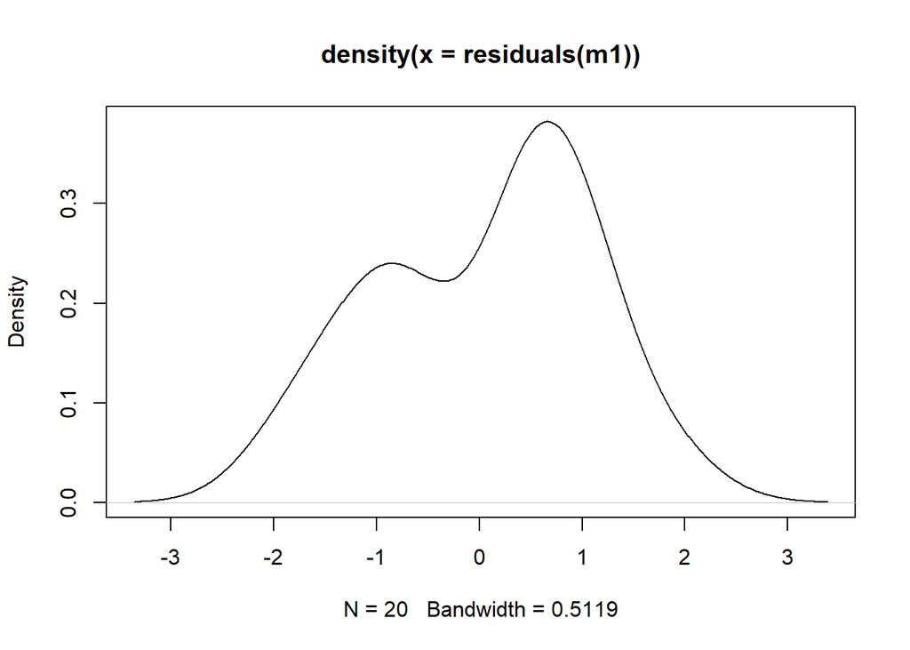

```r
plot(density(residuals(m1)))
```

```r
pchisq(20.431, 16, lower = FALSE)
```

```
## [1] 0.2014327
```

## Beta Binomial Practice

- This accounts for overdispersion

```r
library(aod)
#m2 <- betabin( draft ~ pts + rebs + ast, ~ pts + rebs + ast, data=draft_unreal)
#summary(m2)
# Unable to run a beta binomial regression with bernoulli observations
```

## Coefficient Determination

- Marginal PMF (a function $π_i$, and k=0,1,2…n)
- Joint PMF (a function of the binomial distribution)
- Likelihood function($L(β)$ - Like the PMF but a function of $β$)
- Log likelihood function ($l(β)$) - A non -linear function
- Maximize
- Log likelihood function:

$$\mathbf{l(β)}=\sum_{i=1}^{n} [{k_i}{n_i}
- {n_i}{log(1+e^{n_i})} + log{\binom{n_i}{k_i}}], n_i =
predictors$$

## Interpretation

- Interpreted as a normal distribution because the PMF is shaped like a normal distribution at certain p values
- The shape of the PMF will determine interpretations of the results. This means it could be interpreted as a geometric distribution based on the p value
- As a normal distribution, z values are calculated and compared to standard values
  $$z= \frac{β_j-0}{\sqrt{var(β_j)}}$$

## Binomial vs Poisson

- Poisson best suited for an infinite number of trials
- Moreover, n should be large and p small when using a Poisson distribution to approximate a binomial distribution Conclusion

## GLM Pitfalls

- Unable to maximize an already maximized coefficient (shows up when analyzing groups that are skewed meaning all successes are confined to one group vs failures in the adjacent group).
- A possible phenomenon in biological analysis (like methylation coverage)

## Conclusion

- This is witnessing the evolution of a Linear regression model to a Binomial logistic regression model (Naive Bayes).
- The Primed Bayes is the next step in this evolution.